# sprint15

Hello, my name is Artem. I'm going to review your project!

You can find my comments in green, blue or red boxes like this:

**Success:** if everything is done succesfully

**Improve:** "Improve" comments mean that there are tiny corrections that could help you to make your project better.

**Needs fixing:** if the block requires some corrections. Work can't be accepted with the red comments.

### General feedback

- Thank you for submitting your project! I am really impressed with it.
- Glad to see that the notebook is structured. Keep it up!
- It was a pleasure to review your project.
- You' achieved the required score. Congratulations!
- I've found some tiny mistakes in your project. They'll be easy to fix.
- You can also make your project even better if you work on the "improve" comments.
- While there's room for improvement, on the whole, your project is looking good.
- I believe you can easily fix it!

> Thank you!

### General feedback

- I really appreciate the corrections you sent in! Thanks for taking the time to do so.
- horizontal_flip should be added as a parameter in ImageDataGenerator. Adding it to `train_datagen.flow_from_dataframe` does not make sense.
- In general, all errors were fixed& Thank you.
- This project is accepted. Good luck in the future!

# 1. Exploratory data analysis

```python
import pandas as pd
import tensorflow as tf
from tensorflow.keras.preprocessing.image import ImageDataGenerator
import matplotlib.pyplot as plt
%matplotlib inline
import seaborn as sns
import numpy as np
```

```python
labels = pd.read_csv('/datasets/faces/labels.csv')
train_datagen = ImageDataGenerator(rescale=1./255)
train_gen_flow = train_datagen.flow_from_dataframe(
        dataframe=labels,
        directory='/datasets/faces/final_files/',
        x_col='file_name',
        y_col='real_age',
        target_size=(224, 224),
        batch_size=32,
        class_mode='raw',
        seed=12345)
```

```
Found 7591 validated image filenames.
```

```python
labels.info()
```

```
<class 'pandas.core.frame.DataFrame'>
RangeIndex: 7591 entries, 0 to 7590
Data columns (total 2 columns):
file_name    7591 non-null object
real_age     7591 non-null int64
dtypes: int64(1), object(1)
memory usage: 118.7+ KB
```

**Success:** Data loading was done OK.

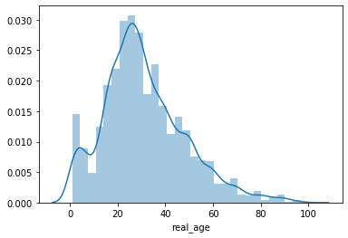

```python
sns.distplot(labels["real_age"],  hist = True, bins=30)
```

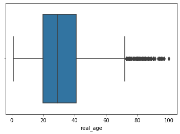

```python
sns.boxplot(labels["real_age"])
```

a bit skewed normal distribution

```python
features, target = next(train_gen_flow)
```

```python
features.shape
```

```
(32, 224, 224, 3)
```

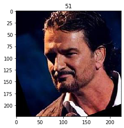

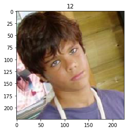

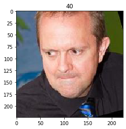

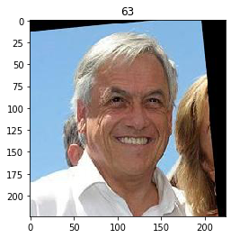

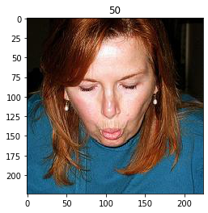

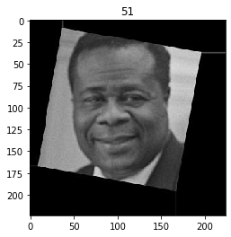

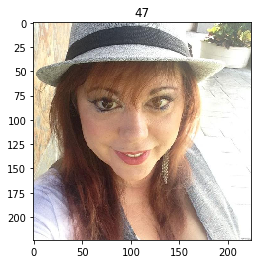

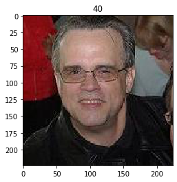

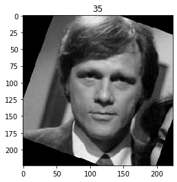

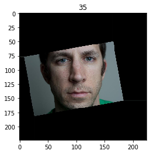

```python
for age, photo in zip(target[:10], features[:10]):
    plt.figure()
    plt.title(age)
    plt.imshow(photo)
```

```python
photo.shape
```

```
(224, 224, 3)
```

we have rotated images (and therefore have to add rotation augmentated images in a training process) 224x224 size, and also we have grayscaled images

**Improve:** It would be better if the age of the person was set in the title.

**Needs fixing:** Please provide some findings and comments about target feature distribution and images (rotation, color, size, etc).

> sure, added

# 2. Model training

Transfer the model training code and the result of printing on the screen here.

(The code in this section is run on a separate GPU platform, so it is not designed as a cell with a code, but as a code in a text cell)

```
import numpy as np
import pandas as pd
from tensorflow.keras.datasets import fashion_mnist
from tensorflow.keras.layers import Conv2D, Flatten, AvgPool2D, Dense, GlobalAveragePooling2D
from tensorflow.keras.models import Sequential
from tensorflow.keras.optimizers import Adam
from tensorflow.keras.preprocessing.image import ImageDataGenerator
from tensorflow.keras.applications.resnet import ResNet50


def load_train(path):
    labels = pd.read_csv(path+'labels.csv')
    train_datagen = ImageDataGenerator(rescale= 1./255, validation_split=0.25)
    train_datagen_flow = train_datagen.flow_from_dataframe(
        dataframe = labels,
        directory = path + 'final_files/',
        x_col='file_name',
        y_col='real_age',
        target_size=(224, 224),
        batch_size=32,
        class_mode='raw',
        subset='training',
        horizontal_flip=True,
        seed=42)
    return train_datagen_flow

def load_test(path):
    labels = pd.read_csv(path+'labels.csv')
    test_datagen = ImageDataGenerator(rescale= 1./255, validation_split=0.25)
    test_datagen_flow = test_datagen.flow_from_dataframe(
        dataframe = labels,
        directory = path + 'final_files/',
        x_col='file_name',
        y_col='real_age',
        target_size=(224, 224),
        batch_size=32,
        class_mode='raw',
        subset='validation',
        seed=42)

    return test_datagen_flow

def create_model(input_shape):

    backbone = ResNet50(input_shape= input_shape,
                    weights='imagenet',
                    include_top= False)

    model = Sequential()
    model.add(backbone)
    model.add(GlobalAveragePooling2D())
    model.add(Dense(1, activation='relu'))
    optimizer = Adam(lr=0.0005)
    model.compile(optimizer=optimizer, loss='mean_squared_error',metrics=['mae'])
    return model


def train_model(model, train_data, test_data, batch_size=None, epochs=10,
                steps_per_epoch=None, validation_steps=None):

    if steps_per_epoch is None:
        steps_per_epoch = len(train_data)
    if validation_steps is None:
        validation_steps = len(test_data)
    model.fit(train_data,
              validation_data= test_data,
              batch_size=batch_size, epochs=epochs,
              steps_per_epoch=steps_per_epoch,
              validation_steps=validation_steps,
              verbose=2)
    return model
```

**Improve:** Using horizontal flip at the training part could help you to increase the training set with valid images.

> right, thank you, added.

```
Epoch 1/10
2020-10-26 22:46:50.462891: I tensorflow/stream_executor/platform/default/dso_loader.cc:44] Successfully opened dynamic library libcublas.so.10
2020-10-26 22:46:50.988793: I tensorflow/stream_executor/platform/default/dso_loader.cc:44] Successfully opened dynamic library libcudnn.so.7
178/178 - 99s - loss: 205.0102 - mae: 10.5819 - val_loss: 317.3405 - val_mae: 13.2126
Epoch 2/10
178/178 - 41s - loss: 96.4598 - mae: 7.4412 - val_loss: 443.4091 - val_mae: 15.8325
Epoch 3/10
178/178 - 41s - loss: 64.0527 - mae: 6.1343 - val_loss: 301.9018 - val_mae: 12.8919
Epoch 4/10
178/178 - 41s - loss: 43.2806 - mae: 5.0341 - val_loss: 149.8389 - val_mae: 9.1190
Epoch 5/10
178/178 - 41s - loss: 29.6981 - mae: 4.2136 - val_loss: 104.9151 - val_mae: 7.5741
Epoch 6/10
178/178 - 41s - loss: 20.6762 - mae: 3.5109 - val_loss: 81.3642 - val_mae: 6.6892
Epoch 7/10
178/178 - 40s - loss: 17.3920 - mae: 3.2108 - val_loss: 87.1265 - val_mae: 6.9833
Epoch 8/10
178/178 - 41s - loss: 13.5037 - mae: 2.8095 - val_loss: 73.9750 - val_mae: 6.4053
Epoch 9/10
178/178 - 41s - loss: 10.7918 - mae: 2.5193 - val_loss: 80.2930 - val_mae: 6.7702
Epoch 10/10
178/178 - 40s - loss: 8.8153 - mae: 2.2726 - val_loss: 69.1264 - val_mae: 6.2419
WARNING:tensorflow:sample_weight modes were coerced from
  ...
    to
  ['...']
60/60 - 10s - loss: 69.1264 - mae: 6.2419
Test MAE: 6.2419
```

**Success:** You've achieved a great score! Well done!

# 3. Trained model analysis

**Improve:** You could say some words about parameters that you've used. Some words about optimzer and learning rate?

> I decided choose half from default value of the learning rate 0.0005 and Adam optimizers which is well balanced on a perfomance and learning sides, it's better firstly try Adam

# Checklist

- [x] Notebook was opened
- [x] The code is error free
- [x] The cells with code have been arranged by order of execution
- [x] The exploratory data analysis has been performed
- [x] The results of the exploratory data analysis have been transferred to the final notebook
- [x] The model's MAE score is not higher than 8
- [x] The model training code has been copied to the final notebook
- [x] The model's printing on the screen result has been transferred to the final notebook
- [x] The findings have been provided based on the results of the model training